# RR_project1

# Imputing Missing Data

```r
total_na <- sum(is.na(activity))

steps_day_avg <- aggregate(steps ~ date, activity, mean)
imputed_activity <- transform(activity, steps = ifelse(is.na(activity$steps), steps_day_avg$steps[match(activity$date,steps_day_avg$date)],activity$steps))
```

Zeroes were imputed for the first day, because all intervals were missing and therefore an average for the day could not be calculated.

```r
imputed_activity[as.character(imputed_activity$date)=='2012-10-01','steps'] <- 0
```

The total number of steps was then recalculated with the imputed data, and a new histogram constructed.

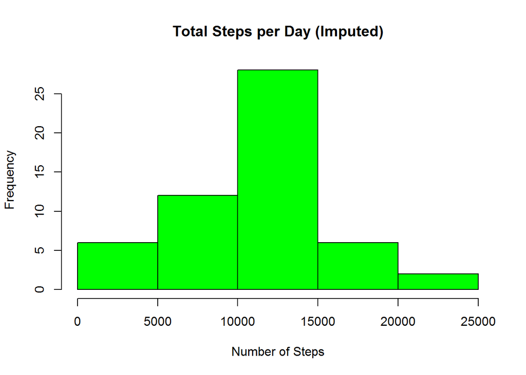

```r
steps_day_sum_i <- aggregate(steps ~ date, imputed_activity, sum)

hist(steps_day_sum_i$steps, main="Total Steps per Day (Imputed)",col="green",xlab="Number of Steps")
```

The mean and median of the dataset with imputed data were then calculated, as well as the difference between the original and new values.

```r
steps_mean_i <- mean(steps_day_sum_i$steps)
steps_median_i <- median(steps_day_sum_i$steps)
mean_diff <- steps_mean_i - steps_mean
median_diff <- steps_median_i - steps_median
total_diff <- sum(steps_day_sum_i$steps) - sum(steps_day_sum$steps)
```

# Are there differences in activity between weekdays and weekends?

Create a new factor variable in the dataset with two levels, ‘weekday’ and ‘weekend’, and create a panel plot to compare activity levels between the two subsets of data.

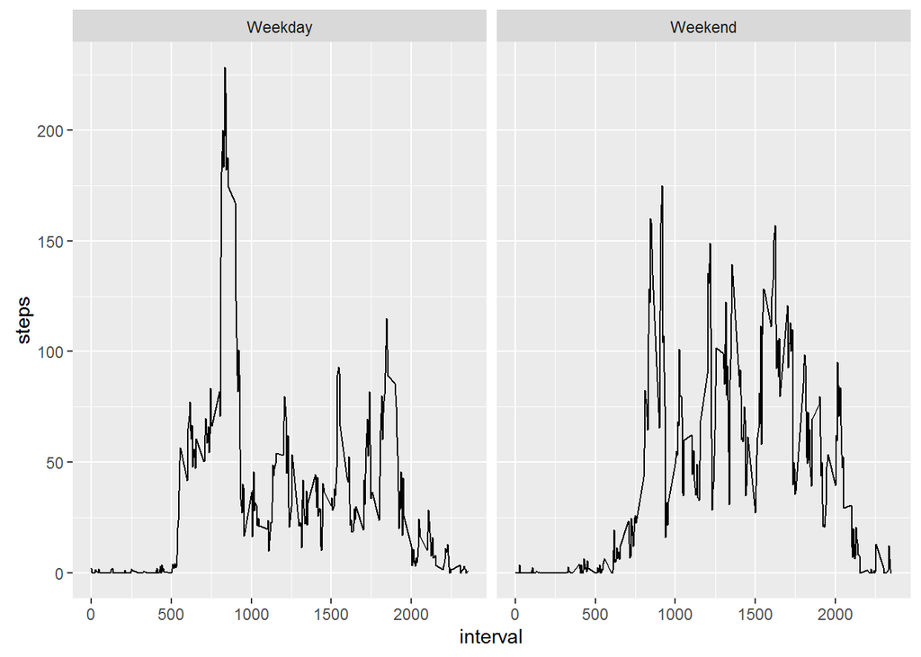

```r
library(ggplot2)
weekday <- c("Monday", "Tuesday", "Wednesday", "Thursday", "Friday")

imputed_activity$day <- as.factor(ifelse(is.element(weekdays(as.Date(imputed_activity$date)),weekday),"Weekday","Weekend"))

steps_int_avg_i <- aggregate(steps ~ interval + day, imputed_activity, mean)

qplot(interval,steps,data=steps_int_avg_i,facets=.~day,geom="line")
```

There is a higher peak earlier on weekdays and more activity overall on weekends.